# Food Security Workshop Survey Results

Myanmar Food Security Cluster

2022/06/01

## Food security workshop survey results

This is a summary of the results of the food security workshop survey on participant preferences. The Food Security Cluster would like to thank all the respondents for sharing their thoughts with us.

### Respondents and organisations

Responses were submitted for the Food Security Workshop survey between the 27th of May and the 1st of June 2022. A total of **33** responses were collected from across **24** organisations:

|  | organisation | number_of_respondents |
| --- | --- | --- |
| 1 | CARE | 2 |
| 2 | Center for Social Integrity (CSI) | 3 |
| 3 | Centre for Development and Environment | 1 |
| 4 | ChildFund Myanmar | 1 |
| 5 | DCA-NCA | 1 |
| 6 | DGRV | 1 |
| 7 | FAO | 5 |
| 8 | FCA (Finn Church Aid) | 1 |
| 9 | Finnish Refugee Council Myanmar, | 1 |
| 10 | Gret | 1 |

[output cut: 14 more lines]

The survey was generally answered by those in senior management positions:

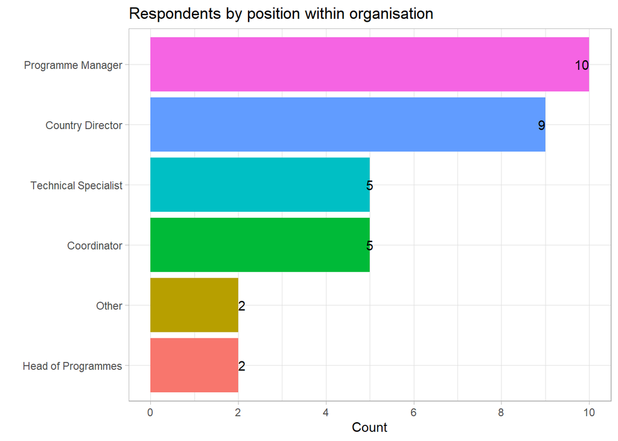

### Topics

The topics that respondents preferred to be covered were:

Most popular topics and number of times they were chosen

| topic | count |
| --- | --- |
| Poverty and the effect of protracted crises on livelihoods and standard of living | 24 |
| Resilience-based activities | 15 |
| Nexus approach (complementarity and value for money) | 12 |
| Partnerships and local expansion | 12 |
| Area-based programming (camps and out of camps) | 10 |
| Natural hazards and food security (climate resistant seeds and new technologies) | 9 |
| Assessments and data quality (MSNA, harmonisation of indicators, PDM) | 7 |
| Establishing IPC in Myanmar (opportunities and challenges) | 5 |
| Synergies with other clusters | 4 |
| Dry zone | 1 |

With these preferences in mind, the Food Security Cluster will prepare a workshop agenda and share it with all partners shortly.

### Meeting dates and formats

A plurality of respondents preferred to hold the workshop in the second half of June.

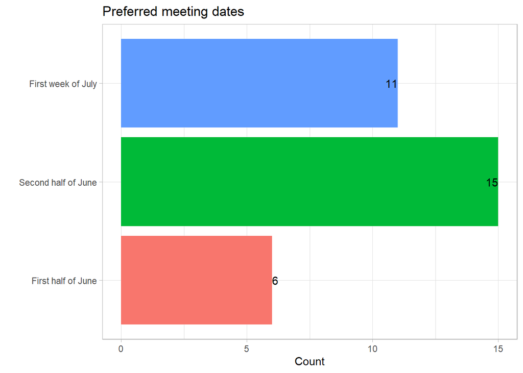

A slight plurality of respondents preferred to hold the workshop over two half days.

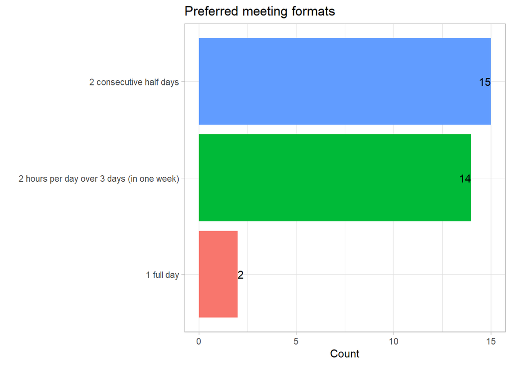

Options will be provided for online, hybrid and in-person set ups. In person meetings will be held simulataneously in Yangon and Bangkok.

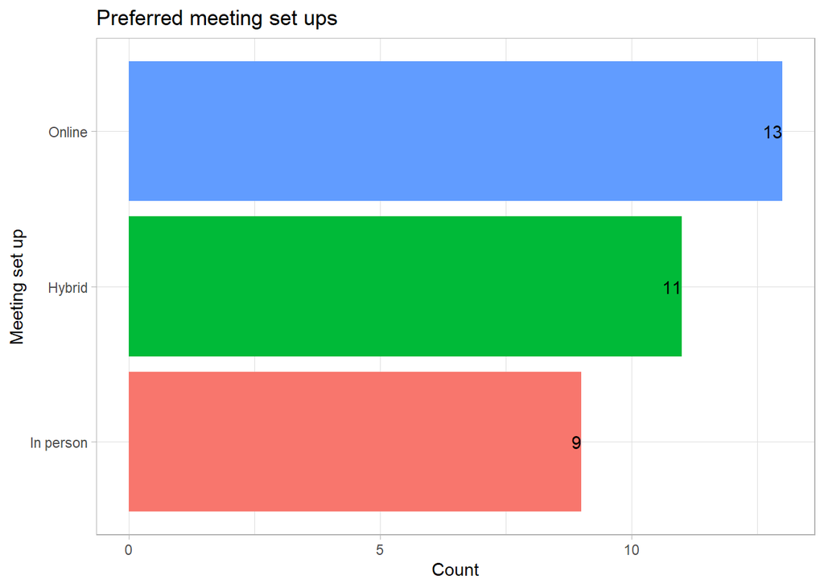

### Other respondent preferences

1/3 of respondents would like to present at the workshop.

| would_you_like_to_present | count |
| --- | --- |
| No | 22 |
| Yes | 11 |

These are the topics they would like to present on. The Food Security Cluster will liaise with these respondents to obtain further details and try our best to include these sessions into the workshop schedule.

List of suggested presentation topics from respondents

| presentation_topic |
| --- |
| Opportunities for insect agriculture for nutrition and livelihood |
| cash payment distribution during conflcit setting and emergencies response |
| The importance of livelihood support and possible intervention capable to restore, protect and improve agriculture based livelihoods |
| Area-based programming (Camps and out of camps) |
| Need, gap and current implementaing partners |
| Food security |

These are the comments provided by respondents.

Suggestions from respondents

| suggestions |
| --- |
| Interested in WFP school nutrition programs in MM and linkage to local food security |
| Within the current context, all sectors need to be engaged in supporting calls for an end to the illegal attacks on civilians. Without an end to the violence against civilians, so much of what we do i… |
| Would appreciate online/hybrid format as I am based in Stockholm, and that the meeting is held to accommodate CET time. |
| How to risk managment and to find alternative solution to implement project activities ( TA issuse , staffs movement ) |
| Workshop should not more than 3 days |
| Presenting options would depend on the topic for discussion. The options I selected above are those I am interested to learn more about and that I would welcome discussion on, not necessarily what we … |
| I interest this becoming training |